# Mechanics

## Differential equations

### Starting example

Let’s consider the first order differential equation

$$\frac{dy(x)}{dx} = 2x$$

$$y(x) = x^2 + C$$

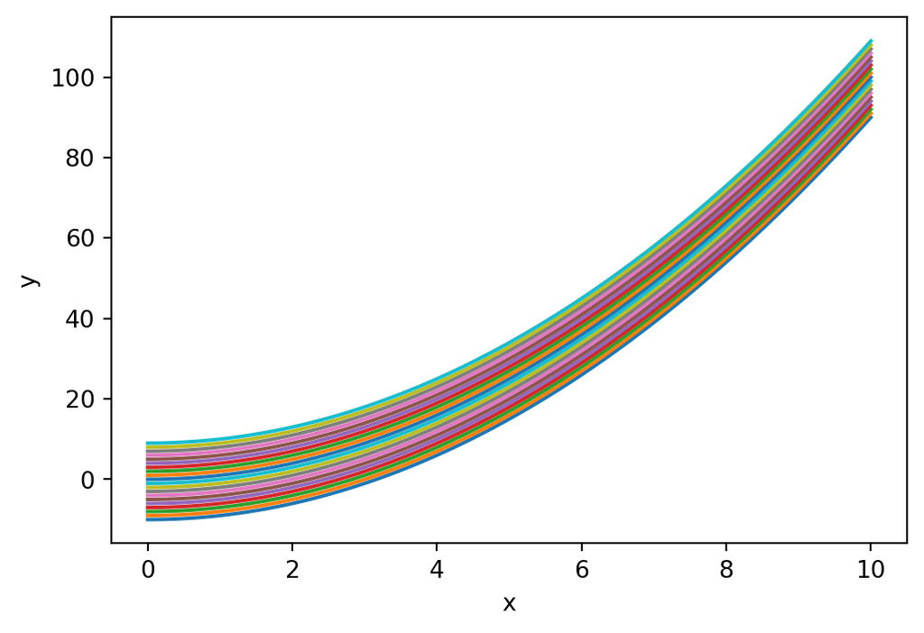

```python
import numpy as np
import matplotlib.pyplot as plt

def y(x, C):
    return x**2 + C

x = np.linspace(0, 10, 100)

fig, ax = plt.subplots(figsize=(6, 4))

for C in range(-10, 10, 1):
    plt.plot(x, y(x, C), label=f'C={C}')

plt.xlabel('x')
plt.ylabel('y')
plt.show()
```

#### Check in geogebra:

- f(x) = x^2 + 3

##### Numerical solution

Remember that derivatives can be approximated by finite differences. The derivative of a function $f(x)$ can be approximated by

$$\frac{df(x)}{dx} \approx \frac{f(x + h) - f(x)}{h}$$

where $h$ is a small number. This is a simple way to approximate the derivative of a function. Let’s use this approximation to solve the differential equation

$$\frac{dy(x)}{dx} = 2x$$

We can approximate the derivative by

$$\frac{y(x + h) - y(x)}{h} = 2x$$

This equation can be solved for $y(x + h)$

$$y(x + h) = y(x) + 2xh$$

This equation can be used to solve the differential equation numerically. We can start from an initial value of $y(x)$ and use the equation above to calculate the value of $y(x + h)$. This value can be used to calculate the next value of $y(x + 2h)$ and so on. This is a simple numerical method to solve differential equations.

Let us compare the numerical solution with the analytical solution.

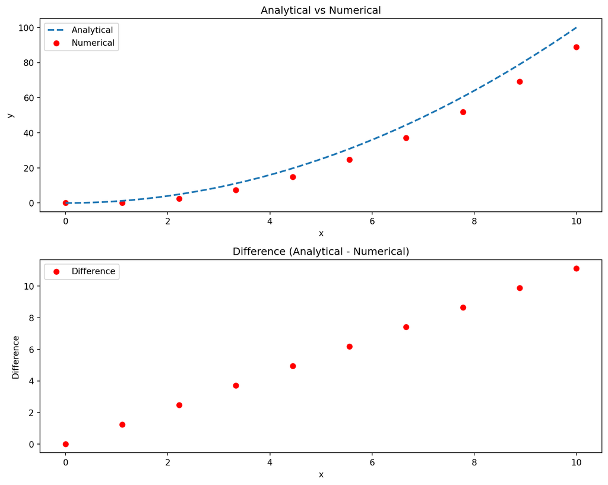

```python
import numpy as np
import matplotlib.pyplot as plt

# Define the derivative dy/dx
def dy_dx(x):
    return 2 * x

# Define the exact analytical solution y(x) for comparison
def y_analytical(x):
    return x**2

# Define a numerical solution for y(x) using the forward Euler method
def y_numerical(x, h):
    y = [0]  # Initialize y with the starting value, assuming y(0) = 0
    for i in range(len(x) - 1):
        y.append(y[-1] + dy_dx(x[i]) * h)  # Update y using dy/dx
    return y

# Set up the x values
plot_x = np.linspace(0, 10, 100)
x = np.linspace(0, 10, 10)
h = x[1] - x[0]  # Step size

# Compute the difference between analytical and numerical solutions
difference = y_analytical(x) - np.array(y_numerical(x, h))

# Set up the figure with two subplots
fig, axs = plt.subplots(2,1, figsize=(10,8))

# Left plot: Analytical and numerical solutions
axs[0].plot(plot_x, y_analytical(plot_x), label='Analytical', linestyle='dashed', linewidth=2)
axs[0].scatter(x, y_numerical(x, h), label='Numerical', linestyle='solid', color='red')
axs[0].set_title('Analytical vs Numerical')
axs[0].set_xlabel('x')
axs[0].set_ylabel('y')
axs[0].legend()

# Right plot: Difference between solutions
axs[1].scatter(x, difference, label='Difference', color='red')
axs[1].set_title('Difference (Analytical - Numerical)')
axs[1].set_xlabel('x')
axs[1].set_ylabel('Difference')
axs[1].legend()

# Adjust layout and show the plots
plt.tight_layout()
plt.show()
```

Difference between the analytical and numerical solutions depends on the step size $h$.

### Second order differential equations

Let’s consider the second order differential equation

$$\frac{d^2y(x)}{dx^2} = -y(x)$$

This is a simple differential equation that can be solved by integration. The solution is

$$y(x) = A \sin(x) + B \cos(x)$$

where $A$ and $B$ are integration constants. This is the general solution of the differential equation. The solution is not unique because the constants $A$ and $B$ can take any value. The solution is a sinusoidal function. The constants $A$ and $B$ determine the amplitude and phase of the sinusoidal function.

#### Numerical solution

From Taylor’s theorem, we know that the second derivative of a function $f(x)$ can be approximated by

$$f(x + h) = f(x) + h \frac{df(x)}{dx} + \frac{h^2}{2} \frac{d^2f(x)}{dx^2} + \ldots$$

also

$$f(x - h) = f(x) - h \frac{df(x)}{dx} + \frac{h^2}{2} \frac{d^2f(x)}{dx^2} + \ldots$$

adding these two equations we get

$$f(x + h) + f(x - h) = 2 f(x) + h^2 \frac{d^2f(x)}{dx^2}$$

so we can approximate the second derivative by

$$\frac{f(x + h) + f(x - h) - 2 f(x)}{h^2} \approx \frac{d^2f(x)}{dx^2}$$

Let’s use this approximation to solve the differential equation

$$\frac{d^2y(x)}{dx^2} = -y(x)$$

We can approximate the second derivative by

$$\frac{y(x + h) + y(x - h) - 2 y(x)}{h^2} = -y(x)$$

This equation can be solved for $y(x + h)$

$$y(x + h) = 2 y(x) - y(x - h) - h^2 y(x)$$

This equation can be used to solve the differential equation numerically. We can start from an initial value of $y(x)$ and $y(x - h)$ and use the equation above to calculate the value of $y(x + h)$. This value can be used to calculate the next value of $y(x + 2h)$ and so on. This is a simple numerical method to solve differential equations.

Let us compare the numerical solution with the analytical solution.

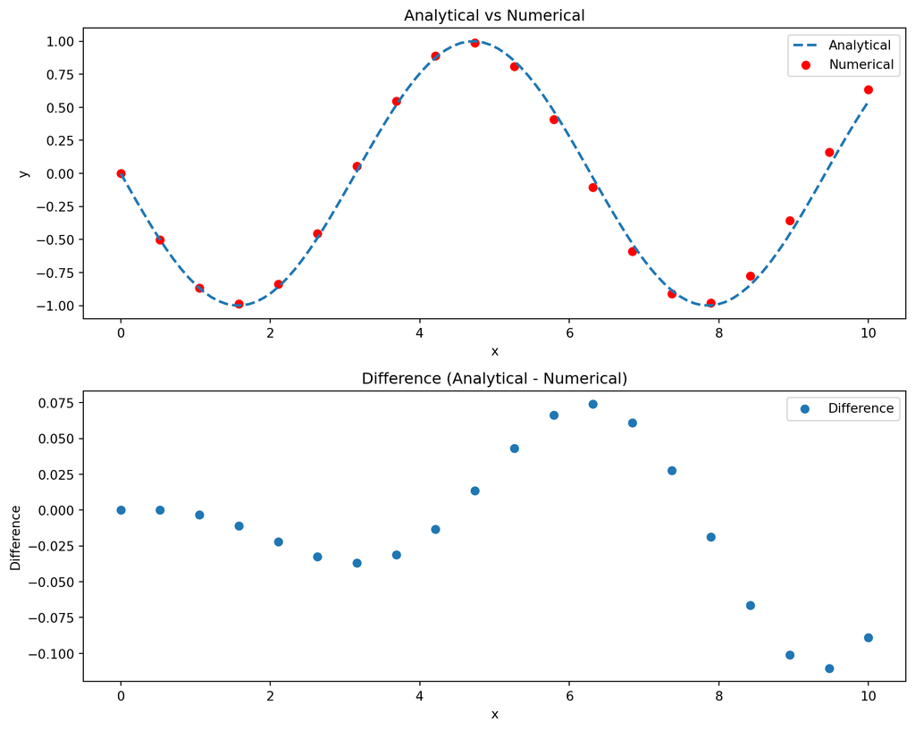

```python
import numpy as np
import matplotlib.pyplot as plt

# Define the second derivative d^2y/dx^2
def d2y_dx2(x):
    return -x

# Define the exact analytical solution y(x) for comparison
def y_analytical(x):
    return -np.sin(x)

# Define a numerical solution for y(x) using the forward Euler method
def y_numerical(x, h):
    y = [0, np.sin(-h)]  # Initialize y with the starting values, assuming y(0) = 0 and y(-h) = sin(-h)
    for i in range(1, len(x) - 1):
        y.append(2 * y[-1] - y[-2] - h**2 * y[-1])  # Update y using d^2y/dx^2
    return y

# Set up the x values
plot_x = np.linspace(0, 10, 100)
x = np.linspace(0, 10, 20)
h = x[1] - x[0]  # Step size

# Compute the difference between analytical and numerical solutions
difference = y_analytical(x) - np.array(y_numerical(x, h))

# Set up the figure with two subplots
fig, axs = plt.subplots(2,1, figsize=(10,8))

# Left plot: Analytical and numerical solutions
axs[0].plot(plot_x, y_analytical(plot_x), label='Analytical', linestyle='dashed', linewidth=2)
axs[0].scatter(x, y_numerical(x, h), label='Numerical', color='red')
axs[0].set_title('Analytical vs Numerical')
axs[0].set_xlabel('x')

axs[0].set_ylabel('y')
axs[0].legend()

# Right plot: Difference between solutions
axs[1].scatter(x, difference, label='Difference')
axs[1].set_title('Difference (Analytical - Numerical)')
axs[1].set_xlabel('x')
axs[1].set_ylabel('Difference')
axs[1].legend()

# Adjust layout and show the plots
plt.tight_layout()
plt.show()
```

## Description of motion

### Movement in 2D Cartesian coordinates

We could start considering moving particle in 1D but 2D examples are more interesting. First we have to define the position of the particle in 2D Cartesian coordinates. The position of the particle is given by the vector $\mathbf{r} = (x, y)$, where $x$ and $y$ are the coordinates of the particle in the $x$ and $y$ axes, respectively. If these coordinates are functions of time, we can write the position vector as $\mathbf{r}(t) = (x(t), y(t))$. This function describes the trajectory of the particle in the $xy$ plane.

$$[a,b]\rightarrow \mathcal{R}^2:
t\rightarrow \mathbf{r}(t) = (x(t), y(t))$$

#### Explanation of Symbols:

- $\mathbf{r}$: Position vector of the particle.
- $(x, y)$: Cartesian coordinates representing the particle’s position in the $x$ and $y$ axes.
- $\mathbf{r}(t)$: Position vector as a function of time, describing the particle’s motion.
- $x(t), y(t)$: Time-dependent functions representing the particle’s coordinates in the $x$ and $y$ axes.
- $[a, b]$: Interval of time during which the particle’s motion is considered.
- $\mathcal{R}^2$: Two-dimensional Cartesian coordinate space.
- $t$: Time variable, used as a parameter for the position function.

#### How Mathematicians Read This Notation:

Mathematicians interpret the notation as follows:

- “$[a,b] \rightarrow \mathcal{R}^2$” means “a mapping (or function) is defined from the interval $[a, b]$ in time to the two-dimensional Cartesian space $\mathcal{R}^2$.”
- “$t \rightarrow \mathbf{r}(t) = (x(t), y(t))$” specifies that for each time $t$ within the interval $[a, b]$, there exists a corresponding position vector $\mathbf{r}(t)$ in $\mathcal{R}^2$, which consists of the time-dependent coordinates $x(t)$ and $y(t)$.
- The overall expression describes a trajectory as a continuous function of time, mapping the progression of time to the corresponding locations in 2D space.

##### Python example

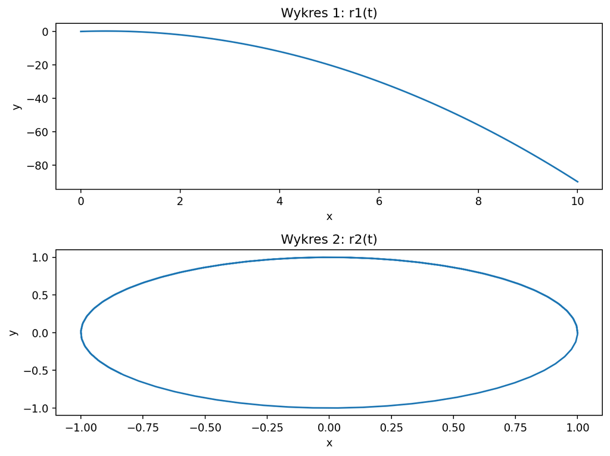

```python
import numpy as np
import matplotlib.pyplot as plt

def r1(t):
    return np.array([t, -t**2 + t])

def r2(t):
    return np.array([np.cos(t), np.sin(t)])

t = np.linspace(0, 10, 100)

fig, axes = plt.subplots(nrows=2, figsize=(8, 6))  # Tworzymy dwa wykresy obok siebie

# Pierwszy wykres
axes[0].plot(r1(t)[0], r1(t)[1])
axes[0].set_xlabel('x')
axes[0].set_ylabel('y')
axes[0].set_title('Wykres 1: r1(t)')

# Drugi wykres
axes[1].plot(r2(t)[0], r2(t)[1])
axes[1].set_xlabel('x')
axes[1].set_ylabel('y')
axes[1].set_title('Wykres 2: r2(t)')

plt.tight_layout()  # Dostosowanie układu
plt.show()
```

##### Geogebra example

- c1 = Curve[t, -t^2+t, t, 0, 10]
- c2 = Curve[cos(t), sin(t), t, 0, 2*pi]
- s = Slider[0,10,.001]
- P = (x(c1(s)),y(c1(s)))
- Q = (x(c2(s)),y(c2(s)))

where

- c1 is a curve $t\rightarrow (t, -t^2+t)$
- c2 is a curve $t\rightarrow (\cos(t), \sin(t))$
- s is a slider from 0 to 10
- P is a point on c1
- Q is a point on c2

Check additional examples in geogebra:

- a=Slider[1,10,1]
- b=Slider[1,10,1]
- Curve[cos(a*t), b*sin(t), t, 0, 20*pi]

In geberal when we create any curve in Geogebra we can create additional point which will be moving along the curve. This is very useful to visualize the motion of the particle.

### Velocity

The velocity of the particle is the derivative of the position vector with respect to time. The velocity vector is defined as

$$\mathbf{v}(t) = \frac{d\mathbf{r}(t)}{dt} = \left(\frac{dx(t)}{dt}, \frac{dy(t)}{dt}\right)$$

The velocity vector describes the speed and direction of the particle at any time $t$. The magnitude of the velocity vector is the speed of the particle. The direction of the velocity vector is the direction of motion of the particle.

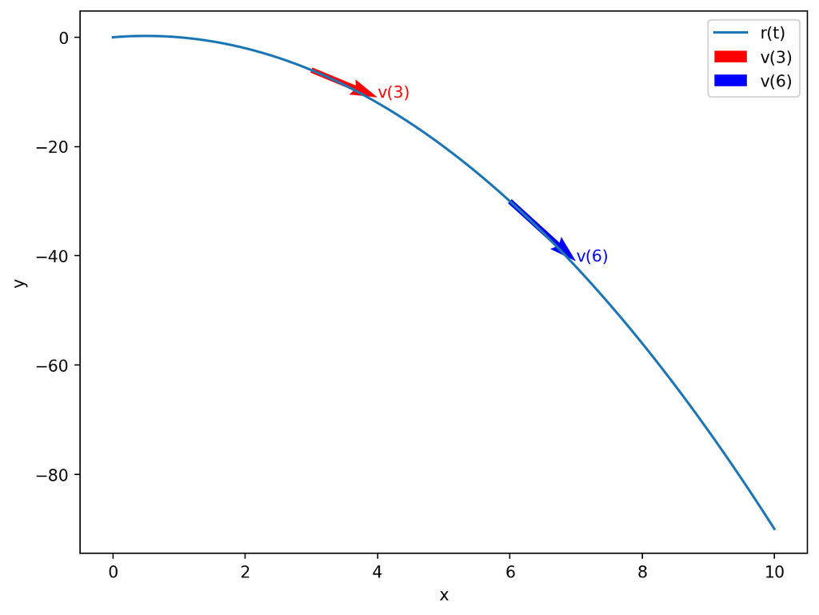

```python
import numpy as np
import matplotlib.pyplot as plt

def r(t):
    return np.array([t, -t**2 + t])

def v(t):
    return np.array([1, -2*t + 1])

t = np.linspace(0, 10, 100)

fig, axes = plt.subplots(figsize=(8, 6))

# whole curve
axes.plot(r(t)[0], r(t)[1], label='r(t)')

# velocity vector at t=3
axes.quiver(r(3)[0], r(3)[1], v(3)[0], v(3)[1], angles='xy', scale_units='xy', scale=1, color='red', label='v(3)')
axes.text(r(3)[0] + v(3)[0], r(3)[1] + v(3)[1], 'v(3)', color='red')
#velocity vector at t=6
axes.quiver(r(6)[0], r(6)[1], v(6)[0], v(6)[1], angles='xy', scale_units='xy', scale=1, color='blue', label='v(6)')
axes.text(r(6)[0] + v(6)[0], r(6)[1] + v(6)[1], 'v(6)', color='blue')

axes.set_xlabel('x')
axes.set_ylabel('y')
axes.legend()
plt.show()
```

we can realze that the in geogebra

- c1 = Curve[t, -t^2+t, t, 0, 10]
- v1 = Derivative[c1]
- s = Slider[0,10,.001]
- P = (x(c1(s)),y(c1(s)))
- vel = Vector[P,P+v1(s)]

where

- c1 is a curve $t\rightarrow (t, -t^2+t)$
- v1 is a velocity function
- s is a slider from 0 to 10
- P is a point on c1
- vel is a velocity vector

## Acceleration

The acceleration of the particle is the derivative of the velocity vector with respect to time. The acceleration vector is defined as

$$\mathbf{a}(t) = \frac{d\mathbf{v}(t)}{dt} = \left(\frac{d^2x(t)}{dt^2}, \frac{d^2y(t)}{dt^2}\right)$$

The acceleration vector describes the rate of change of the velocity of the particle at any time $t$. The magnitude of the acceleration vector is the rate of change of the speed of the particle. The direction of the acceleration vector is the direction of the change of the velocity of the particle.

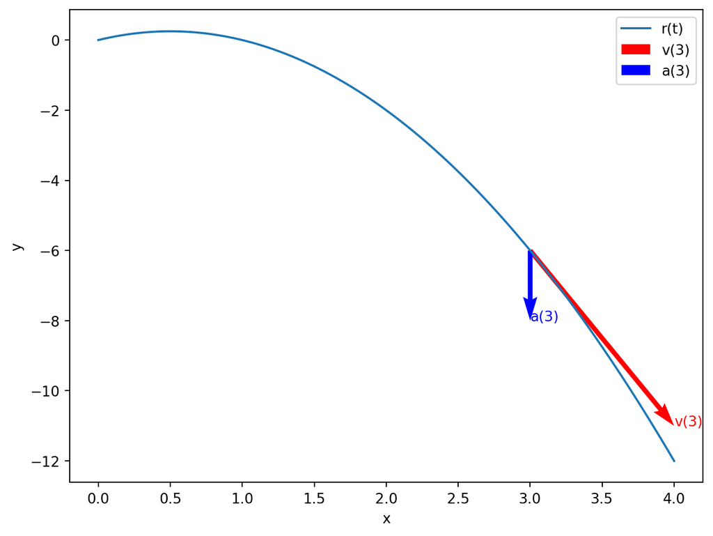

```python
import numpy as np
import matplotlib.pyplot as plt

def r(t):
    return np.array([t, -t**2 + t])

def v(t):
    return np.array([1, -2*t + 1])

def a(t):
    return np.array([0, -2])

t = np.linspace(0, 4, 100)

fig, axes = plt.subplots(figsize=(8, 6))

# whole curve
axes.plot(r(t)[0], r(t)[1], label='r(t)')
# velocity vector at t=3
axes.quiver(r(3)[0], r(3)[1], v(3)[0], v(3)[1], angles='xy', scale_units='xy', scale=1, color='red', label='v(3)')
axes.text(r(3)[0] + v(3)[0], r(3)[1] + v(3)[1], 'v(3)', color='red')
# acceleration vector at t=3
axes.quiver(r(3)[0], r(3)[1], a(3)[0], a(3)[1], angles='xy', scale_units='xy', scale=1, color='blue', label='a(3)')
axes.text(r(3)[0] + a(3)[0], r(3)[1] + a(3)[1], 'a(3)', color='blue')

axes.set_xlabel('x')
axes.set_ylabel('y')
axes.legend()
plt.show()
```

we can realze that the in geogebra

- c1 = Curve[t, -t^2+t, t, 0, 10]
- v1 = Derivative[c1]
- a1 = Derivative[v1]
- s = Slider[0,10,.001]
- P = (x(c1(s)),y(c1(s)))
- vel = Vector[P,P+v1(s)]
- acc = Vector[P,P+a1(s)]

where

- c1 is a curve $t\rightarrow (t, -t^2+t)$
- v1 is a velocity function
- a1 is an acceleration function
- s is a slider from 0 to 10
- P is a point on c1
- vel is a velocity vector
- acc is an acceleration vector

# Newton’s laws of motion

Revolutions in physics started with Newton’s laws of motion. These laws describe the motion of particles in space. The first law states that a particle moves with constant velocity if no external forces act on it. The second law states that the acceleration of a particle is proportional to the force acting on it. The third law states that forces always occur in pairs. If one object exerts a force on another object, the second object exerts an equal and opposite force on the first object. These laws are the foundation of classical mechanics.

## Newton’s first law

Newton’s first law states that a particle moves with constant velocity if no external forces act on it. This law is also known as the law of inertia. The law of inertia states that an object at rest stays at rest and an object in motion stays in motion with the same speed and in the same direction unless acted upon by an external force. This law is a consequence of the conservation of momentum. The momentum of a particle is the product of its mass and velocity. The momentum of a particle is conserved if no external forces act on it.

## Newton’s second law

Newton’s second law states that the acceleration of a particle is proportional to the force acting on it. The acceleration of a particle is the rate of change of its velocity. The force acting on a particle is the product of its mass and acceleration. The force acting on a particle is equal to the rate of change of its momentum. The second law can be written as

$$\mathbf{F}(t) = m \mathbf{a}(t)$$

where $\mathbf{F}(t)=(F_x(t), F_y(t), F_z(t))$ is the force acting on the particle, $m$ is the mass of the particle, and $\mathbf{a}=(x''(t), y''(t),z''(t))$ is the acceleration of the particle.

Above equation can be written as a set of three equations

$$\begin{align*}
\frac{d^2 x(t)}{dt^2} &= \frac{F_x(t)}{m} \\
\frac{d^2 y(t)}{dt^2} &= \frac{F_y(t)}{m}\\
\frac{d^2 z(t)}{dt^2} &= \frac{F_z(t)}{m}
\end{align*}$$

### Bounduary conditions

To solve these equations we need to know the initial position and velocity of the particle. These are the boundary conditions of the problem. The boundary conditions are the initial values of the position and velocity of the particle. The boundary conditions determine the trajectory of the particle in space. The boundary conditions can be used to solve the differential equations of motion.

## Newton’s third law

Newton’s third law states that forces always occur in pairs. If one object exerts a force on another object, the second object exerts an equal and opposite force on the first object. This law is also known as the law of action and reaction. The law of action and reaction states that for every action there is an equal and opposite reaction. This law is a consequence of the conservation of momentum. The momentum of a system is conserved if no external forces act on it.

## Projectile motion

Equations of motion for a particle in free fall are

$$\begin{align*}
\frac{d^2 x(t)}{dt^2} &= 0 \\
\frac{d^2 y(t)}{dt^2} &= -g
\end{align*}$$

where $g$ is the acceleration due to gravity. The acceleration of the particle in the $x$ direction is zero. The acceleration of the particle in the $y$ direction is equal to the acceleration due to gravity. The force acting on the particle is the force of gravity. The force of gravity is equal to the mass of the particle times the acceleration due to gravity. The force of gravity is equal to the weight of the particle. The weight of the particle is the force of gravity acting on the particle.

#### Analytical solution

The analytical solution of the equations of motion for a particle in free fall is

$$\begin{align*}
x(t) &= v_{0x} t + x_0 \\
y(t) &= -\frac{1}{2} g t^2 + v_{0y} t + y_0
\end{align*}$$

where $v_{0x}$ and $v_{0y}$ are the initial velocities of the particle in the $x$ and $y$ directions, respectively, and $x_0$ and $y_0$ are the initial positions of the particle in the $x$ and $y$ directions, respectively. The initial velocities and positions of the particle are the boundary conditions of the problem. The boundary conditions determine the trajectory of the particle in space.

#### Numerical solution

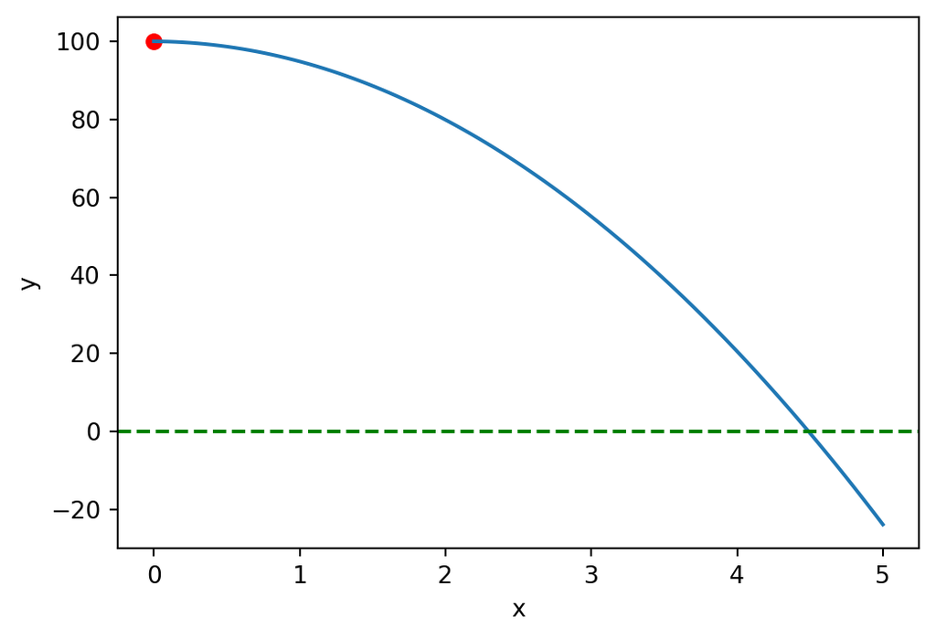

```python
import numpy as np
import matplotlib.pyplot as plt

F = (0, -9.81)  # Force of gravity
m = 1  # Mass of the particle
x_0, y_0 = 0, 100  # Initial position
v_x0, v_y0 = 1, 0  # Initial velocity

def a(t):
    return F[0] / m, F[1] / m

t= np.linspace(0, 5, 100)
h= t[1] - t[0]

x = [x_0]
y = [y_0]

for i in range(1, len(t)):
    a_x, a_y = a(t[i])
    v_x0 += a_x * h
    v_y0 += a_y * h
    x.append(x[i-1] + v_x0 * h)
    y.append(y[i-1] + v_y0 * h)

fig, ax = plt.subplots(figsize=(6, 4))
ax.plot(x, y)
ax.set_xlabel('x')
ax.set_ylabel('y')
# add goung level
ax.axhline(0, color='green', linestyle='dashed', label='Ground level')
# add initial position
ax.scatter(x_0, y_0, color='red', label='Initial position')
plt.show()
```

## Simple harmonic motion in 2D

Let $\mathbb{F}=(-kx,-ky)$ be the force acting on the particle. The equations of motion are

$$\begin{align*}
\frac{d^2 x(t)}{dt^2} &= -\frac{k}{m} x(t) \\
\frac{d^2 y(t)}{dt^2} &= -\frac{k}{m} y(t)
\end{align*}$$

where $k$ is the spring constant and $m$ is the mass of the particle. The acceleration of the particle in the $x$ direction is proportional to the position of the particle in the $x$ direction. The acceleration of the particle in the $y$ direction is proportional to the position of the particle in the $y$ direction. The force acting on the particle is the force of a spring. The force of a spring is equal to the spring constant times the position of the particle. The force of a spring is equal to the force acting on the particle.

#### Analytical solution

The analytical solution of the equations of motion for a particle in simple harmonic motion is

$$\begin{align*}
x(t) &= A_x \sin(\omega t) + B_x \cos(\omega t) \\
y(t) &= A_y \sin(\omega t) + B_y \cos(\omega t)
\end{align*}$$

where $A_x$, $B_x$, $A_y$, and $B_y$ are the amplitudes of the particle in the $x$ and $y$ directions, respectively, and $\omega$ is the angular frequency of the particle. The angular frequency of the particle is equal to the square root of the spring constant divided by the mass of the particle. The phase angle $\phi$ is the initial phase of the particle. The initial phase of the particle is the phase of the particle at time $t=0$. The initial phase of the particle is the boundary condition of the problem. The boundary condition determines the trajectory of the particle in space.

#### Numerical solution

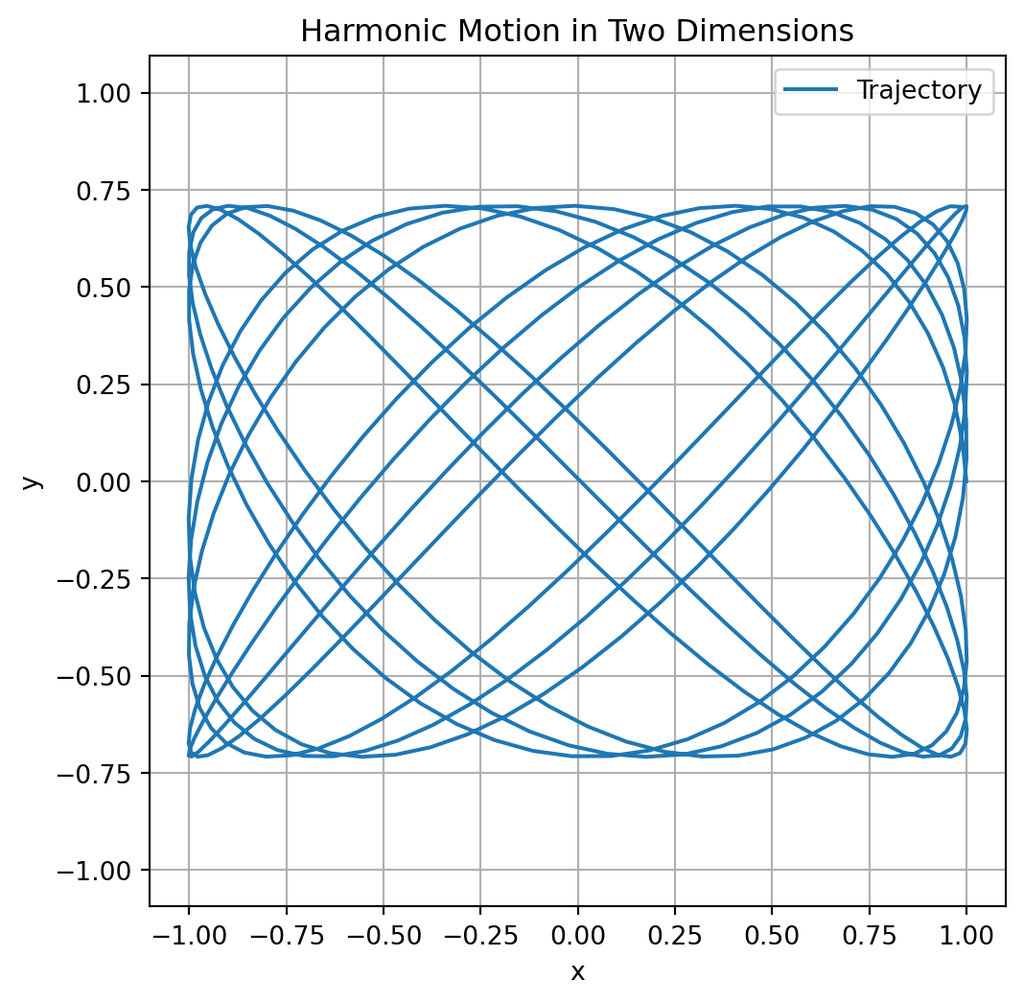

```python
import numpy as np
import matplotlib.pyplot as plt

# Parameters
k_x, k_y = 1, 2  # Spring constants
m = 1  # Mass of the particle
x_0, y_0 = 1, 0  # Initial position
v_x0, v_y0 = 0, 1  # Initial velocity

# Acceleration function
def acceleration(x, y, k_x,k_y, m):
    a_x = -k_x / m * x
    a_y = -k_y / m * y
    return a_x, a_y

# Simulation time
t = np.linspace(0, 50, 500)
dt = t[1] - t[0]

# Positions and velocities
x, y = [x_0], [y_0]
v_x, v_y = v_x0, v_y0

for i in range(1, len(t)):
    a_x, a_y = acceleration(x[-1], y[-1], k_x,k_y, m)
    # Update velocity (Euler step)
    v_x += a_x * dt
    v_y += a_y * dt
    # Update position (Euler step)
    x.append(x[-1] + v_x * dt)
    y.append(y[-1] + v_y * dt)

# Plotting the trajectory
plt.figure(figsize=(6, 6))
plt.plot(x, y, label="Trajectory")
plt.xlabel('x')
plt.ylabel('y')
plt.title('Harmonic Motion in Two Dimensions')
plt.legend()
plt.grid()
plt.axis('equal')
plt.show()
```

## Pendulum Motion

### Introduction

The motion of a simple pendulum is a classic example of harmonic motion. A pendulum consists of a mass $m$ (called the bob) attached to a string or rod of length $L$, which is fixed at one end and free to swing back and forth under the influence of gravity. For small angles, the motion can be approximated as simple harmonic motion.

### Equations of Motion

The equation of motion for a pendulum is derived from Newton’s second law. The force acting on the pendulum is the component of the gravitational force tangential to the arc of its swing:

$$F = -mg \sin(\theta)$$

Using the relationship $F = ma$ and the angular acceleration $a = L \frac{d^2 \theta}{dt^2}$, we get:

$$L \frac{d^2 \theta}{dt^2} = -g \sin(\theta)$$

Dividing through by $L$, the equation becomes:

$$\frac{d^2 \theta}{dt^2} + \frac{g}{L} \sin(\theta) = 0$$

For small angles ($\sin(\theta) \approx \theta$), the equation simplifies to:

$$\frac{d^2 \theta}{dt^2} + \frac{g}{L} \theta = 0$$

This is the equation for simple harmonic motion with angular frequency:

$$\omega = \sqrt{\frac{g}{L}}$$

### Analytical Solution

The analytical solution for small angles is:

$$\theta(t) = \theta_0 \cos(\omega t + \phi)$$

where: - $\theta_0$ is the initial angular displacement. - $\phi$ is the phase constant, determined by initial conditions.

### Numerical Solution

For larger angles, the small-angle approximation does not hold, and we need to solve the original nonlinear equation numerically. We can use the finite difference method to approximate the solution.

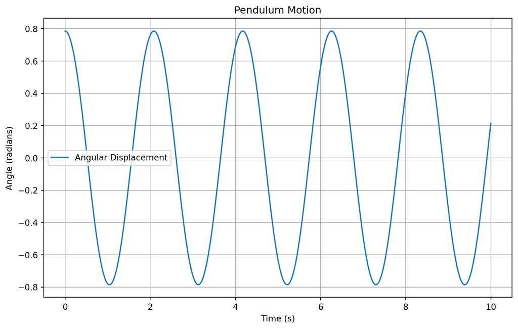

```python
import numpy as np
import matplotlib.pyplot as plt

# Parameters
g = 9.81  # Acceleration due to gravity (m/s^2)
L = 1.0   # Length of the pendulum (m)
theta_0 = np.pi / 4  # Initial angle (radians)

# Time settings
T = 10  # Total time (s)
N = 10_000  # Number of time steps
dt = T / N

# Arrays to store values
t = np.linspace(0, T, N)
theta = np.zeros(N)
omega = np.zeros(N)  # Angular velocity

# Initial conditions
theta[0] = theta_0
omega[0] = 0

# Numerical integration (Euler method)
for i in range(1, N):
    alpha = -(g / L) * np.sin(theta[i - 1])  # Angular acceleration
    omega[i] = omega[i - 1] + alpha * dt  # Update angular velocity
    theta[i] = theta[i - 1] + omega[i] * dt  # Update angle

# Plotting
plt.figure(figsize=(10, 6))
plt.plot(t, theta, label="Angular Displacement")
plt.title("Pendulum Motion")
plt.xlabel("Time (s)")
plt.ylabel("Angle (radians)")
plt.grid()
plt.legend()
plt.show()
```

### Phase Space Representation

The motion of the pendulum can also be visualized in phase space, where the angular displacement $\theta$ is plotted against the angular velocity $\omega$.

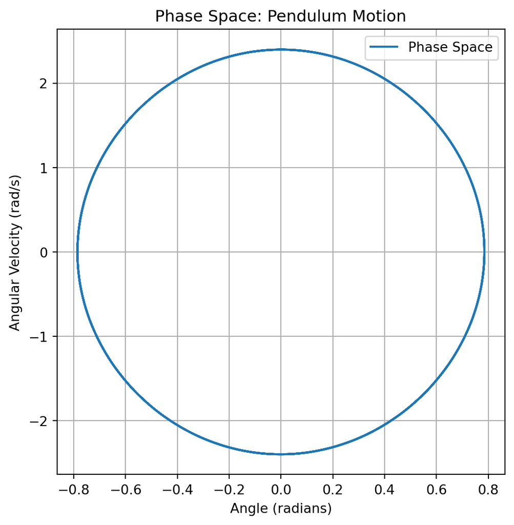

```python
plt.figure(figsize=(6, 6))
plt.plot(theta, omega, label="Phase Space")
plt.title("Phase Space: Pendulum Motion")
plt.xlabel("Angle (radians)")
plt.ylabel("Angular Velocity (rad/s)")
plt.grid()
plt.legend()
plt.show()
```

### Energy Analysis

The total mechanical energy of the pendulum is conserved (assuming no damping). The total energy is the sum of kinetic and potential energy:

$$E = K + U$$

- Kinetic energy: $K = \frac{1}{2} m v^2$
- Potential energy: $U = m g h$

For a pendulum:

$$v = L \frac{d\theta}{dt}, \quad h = L (1 - \cos\theta)$$

Thus, the total energy becomes:

$$E = \frac{1}{2} m L^2 \left(\frac{d\theta}{dt}\right)^2 + m g L (1 - \cos\theta)$$

The energy remains constant over time, which can be verified numerically.

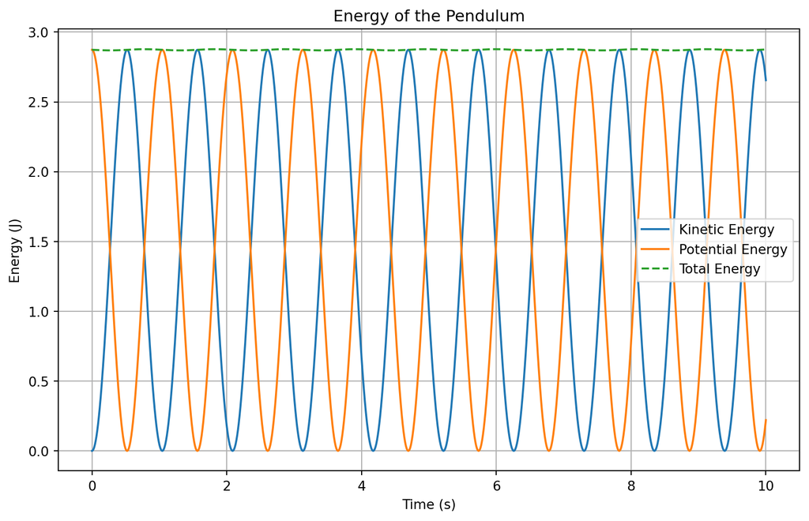

```python
# Calculate energies
kinetic_energy = 0.5 * m * (L * omega)**2
potential_energy = m * g * L * (1 - np.cos(theta))
total_energy = kinetic_energy + potential_energy

# Plot energies
plt.figure(figsize=(10, 6))
plt.plot(t, kinetic_energy, label="Kinetic Energy")
plt.plot(t, potential_energy, label="Potential Energy")
plt.plot(t, total_energy, label="Total Energy", linestyle="dashed")
plt.title("Energy of the Pendulum")
plt.xlabel("Time (s)")
plt.ylabel("Energy (J)")
plt.grid()
plt.legend()
plt.show()
```

## Circular Motion

### Introduction

Circular motion refers to the movement of an object along a circular path. This motion can be uniform (constant speed) or non-uniform (variable speed). For simplicity, we will consider uniform circular motion, where the speed of the object is constant. The position, velocity, and acceleration vectors in circular motion exhibit interesting properties:

- The velocity vector is always tangent to the circle.
- The acceleration vector (centripetal acceleration) always points toward the center of the circle.

### Equations of Motion

Assume an object moves along a circular path of radius $R$ with constant angular velocity $\omega$.

#### Position Vector

The position of the object at time $t$ can be described in terms of the angle $\theta(t)$ it makes with the reference axis:

$$\mathbf{r}(t) = R \cos(\omega t) \hat{i} + R \sin(\omega t) \hat{j}$$

#### Velocity Vector

The velocity is the derivative of the position vector with respect to time:

$$\mathbf{v}(t) = \frac{d\mathbf{r}(t)}{dt} = -R \omega \sin(\omega t) \hat{i} + R \omega \cos(\omega t) \hat{j}$$

The magnitude of the velocity is constant and equals:

$$|\mathbf{v}(t)| = R \omega$$

#### Acceleration Vector

The acceleration is the derivative of the velocity vector with respect to time:

$$\mathbf{a}(t) = \frac{d\mathbf{v}(t)}{dt} = -R \omega^2 \cos(\omega t) \hat{i} - R \omega^2 \sin(\omega t) \hat{j}$$

The acceleration vector always points toward the center of the circle (centripetal acceleration), and its magnitude is:

$$|\mathbf{a}(t)| = R \omega^2$$

### Properties (Explicit Calculations)

1. **Velocity and Position Perpendicularity:**

   The dot product of the position vector $\mathbf{r}(t)$ and velocity vector $\mathbf{v}(t)$ is:

   $$\mathbf{r}(t) \cdot \mathbf{v}(t) = \left[R \cos(\omega t)\right] \left[-R \omega \sin(\omega t)\right] + \left[R \sin(\omega t)\right] \left[R \omega \cos(\omega t)\right]$$

   Simplifying:

   $$\mathbf{r}(t) \cdot \mathbf{v}(t) = -R^2 \omega \cos(\omega t) \sin(\omega t) + R^2 \omega \sin(\omega t) \cos(\omega t) = 0$$

   This confirms that $\mathbf{r}(t)$ and $\mathbf{v}(t)$ are perpendicular.
2. **Acceleration Direction Toward the Center:**

   The acceleration vector $\mathbf{a}(t)$ is proportional to the negative of the position vector:

   $$\mathbf{a}(t) = -\omega^2 \mathbf{r}(t)$$

   Substituting $\mathbf{r}(t)$:

   $$\mathbf{a}(t) = -\omega^2 \left[R \cos(\omega t) \hat{i} + R \sin(\omega t) \hat{j}\right]$$

   This shows that $\mathbf{a}(t)$ always points toward the center of the circle.

### Numerical Example

We will visualize the position, velocity, and acceleration at two distinct points along the circular path.

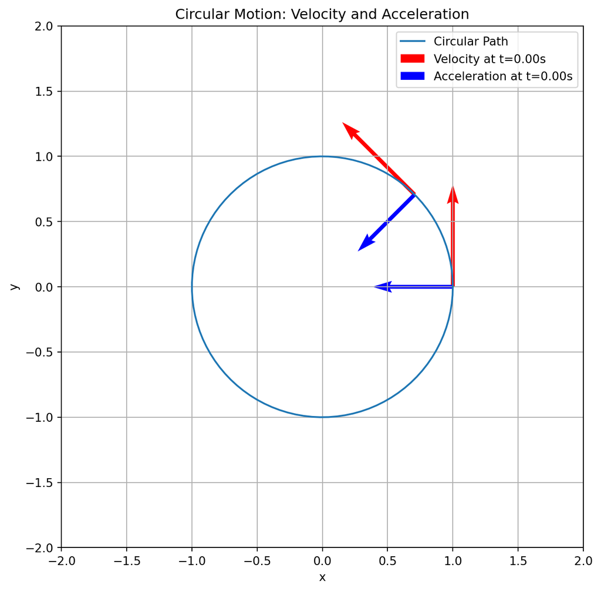

```python
import numpy as np
import matplotlib.pyplot as plt

# Parameters
R = 1  # Radius of the circle
omega =  np.pi/4  # Angular velocity (rad/s)
T = 1  # Time period (s)
t_points = [0, T]  # Time points to analyze

# Calculate vectors at specific points
positions = [(R * np.cos(omega * t), R * np.sin(omega * t)) for t in t_points]
velocities = [(-R * omega * np.sin(omega * t), R * omega * np.cos(omega * t)) for t in t_points]
accelerations = [(-R * omega**2 * np.cos(omega * t), -R * omega**2 * np.sin(omega * t)) for t in t_points]

# Plot the circle and vectors
fig, ax = plt.subplots(figsize=(8, 8))
theta = np.linspace(0, 2 * np.pi, 100)
x_circle = R * np.cos(theta)
y_circle = R * np.sin(theta)
ax.plot(x_circle, y_circle, label="Circular Path")

for i, t in enumerate(t_points):
    x, y = positions[i]
    vx, vy = velocities[i]
    axx, axy = accelerations[i]

    ax.quiver(x, y, vx, vy, color="red", angles="xy", scale_units="xy", scale=1, label=f"Velocity at t={t:.2f}s" if i == 0 else None)
    ax.quiver(x, y, axx, axy, color="blue", angles="xy", scale_units="xy", scale=1, label=f"Acceleration at t={t:.2f}s" if i == 0 else None)

ax.set_aspect('equal', adjustable='box')
ax.set_title("Circular Motion: Velocity and Acceleration")
ax.set_xlabel("x")
ax.set_ylabel("y")
ax.set_xlim(-2, 2)
ax.set_ylim(-2, 2)
ax.legend()
ax.grid()
plt.show()
```

## Universal Law of Gravitation

### Introduction

The Universal Law of Gravitation, formulated by Sir Isaac Newton, describes the gravitational force between two masses. It states that every particle of matter in the universe attracts every other particle with a force that is directly proportional to the product of their masses and inversely proportional to the square of the distance between their centers.

### Mathematical Formulation

The gravitational force $\mathbf{F}$ between two masses $m_1$ and $m_2$ separated by a distance $r$ is given by:

$$\mathbf{F} = -G \frac{m_1 m_2}{r^2} \hat{r}$$

Where: - $G$ is the gravitational constant ($6.674 \times 10^{-11} \ \mathrm{Nm^2/kg^2}$), - $\hat{r}$ is the unit vector pointing from one mass to the other, - $m_1$ and $m_2$ are the masses of the two bodies, - $r$ is the distance between the centers of the masses.

### Gravitational Field

The gravitational field $\mathbf{g}$ at a distance $r$ from a mass $M$ is defined as the force per unit mass exerted by $M$:

$$\mathbf{g} = -G \frac{M}{r^2} \hat{r}$$

This field points toward the mass $M$ and has a magnitude:

$$|\mathbf{g}| = G \frac{M}{r^2}$$

### Orbital Motion

Gravitational force is responsible for the orbital motion of planets, moons, and satellites. The centripetal force required for circular motion is provided by gravity:

$$F = \frac{mv^2}{r} = G \frac{mM}{r^2}$$

From this, the orbital velocity $v$ of a body of mass $m$ around a central mass $M$ is:

$$v = \sqrt{G \frac{M}{r}}$$

The orbital period $T$ of the body can also be derived:

$$T = 2\pi \sqrt{\frac{r^3}{GM}}$$

### Escape Velocity

Escape velocity is the minimum velocity required for an object to escape the gravitational pull of a planet or celestial body without further propulsion. It is given by:

$$v_\text{escape} = \sqrt{2G \frac{M}{r}}$$

### Numerical Example: Gravitational Force Between Earth and Moon

We calculate the gravitational force between Earth and Moon using the following values: - Mass of Earth ($M_\text{Earth}$): $5.972 \times 10^{24} \ \mathrm{kg}$ - Mass of Moon ($M_\text{Moon}$): $7.348 \times 10^{22} \ \mathrm{kg}$ - Distance between Earth and Moon ($r$): $3.844 \times 10^8 \ \mathrm{m}$

```python
# Constants
G = 6.674e-11  # Gravitational constant (N m^2/kg^2)
M_earth = 5.972e24  # Mass of Earth (kg)
M_moon = 7.348e22  # Mass of Moon (kg)
r = 3.844e8  # Distance between Earth and Moon (m)

# Gravitational force
F = G * M_earth * M_moon / r**2

# Output the result
print(f"The gravitational force between Earth and Moon is {F:.2e} N")
```

```
The gravitational force between Earth and Moon is 1.98e+20 N
```

### Visualization: Gravitational Field

We visualize the gravitational field of a central mass $M$ in 2D space.

[figure not shown]

```python
import numpy as np
import matplotlib.pyplot as plt

# Parameters
M = 5.972e24  # Mass of central body (kg)
G = 6.674e-11  # Gravitational constant

# Grid for visualization
x = np.linspace(-10, 10, 100)
y = np.linspace(-10, 10, 100)
X, Y = np.meshgrid(x, y)
R = np.sqrt(X**2 + Y**2)

# Avoid division by zero
R[R == 0] = np.nan

# Gravitational field
Fx = -G * M * X / R**3
Fy = -G * M * Y / R**3

# Plot field
plt.figure(figsize=(8, 8))
plt.quiver(X, Y, Fx, Fy, scale=1e10, color='blue')
plt.xlabel('x (m)')
plt.ylabel('y (m)')
plt.title('Gravitational Field')
plt.grid()
plt.gca().set_aspect('equal', adjustable='box')
plt.show()
```

### Gravitational Potential Energy

The gravitational potential energy $U$ of a two-body system is given by:

$$U = -G \frac{m_1 m_2}{r}$$

This energy is negative because the gravitational force is attractive, and the potential energy is zero at infinite separation.

### Applications of Universal Gravitation

1. **Planetary Orbits:** Predicting the motion of planets and moons in their orbits.
2. **Space Travel:** Calculating escape velocities and transfer orbits for spacecraft.
3. **Tidal Effects:** Understanding the gravitational interaction between Earth and Moon causing ocean tides.
4. **Astrophysics:** Studying gravitational interactions in galaxies and black holes.

### Advanced Topic: Gravitational Slingshot

Gravitational slingshot, or gravity assist, is a technique used in space travel to accelerate a spacecraft by passing it close to a planet. The gravitational force of the planet alters the spacecraft’s trajectory and speed, conserving energy and allowing the spacecraft to gain velocity relative to its target.

This technique relies on the conservation of momentum and energy in the spacecraft-planet system. It is widely used for interplanetary missions, such as Voyager and Cassini.

```python
# Example parameters for gravitational slingshot visualization
planet_velocity = np.array([0, 30])  # Planet velocity (km/s)
initial_velocity = np.array([10, 0])  # Initial spacecraft velocity (km/s)
relative_velocity = initial_velocity - planet_velocity
final_velocity = relative_velocity + 2 * planet_velocity

print("Initial velocity relative to the planet:", relative_velocity, "km/s")
print("Final velocity after slingshot:", final_velocity, "km/s")
```

```
Initial velocity relative to the planet: [ 10 -30] km/s
Final velocity after slingshot: [10 30] km/s
```

This example demonstrates how a spacecraft gains speed using gravitational slingshot.